# Individual electricity demand modelling: solution

1. Load data and fit a basic Gaussian GAM:

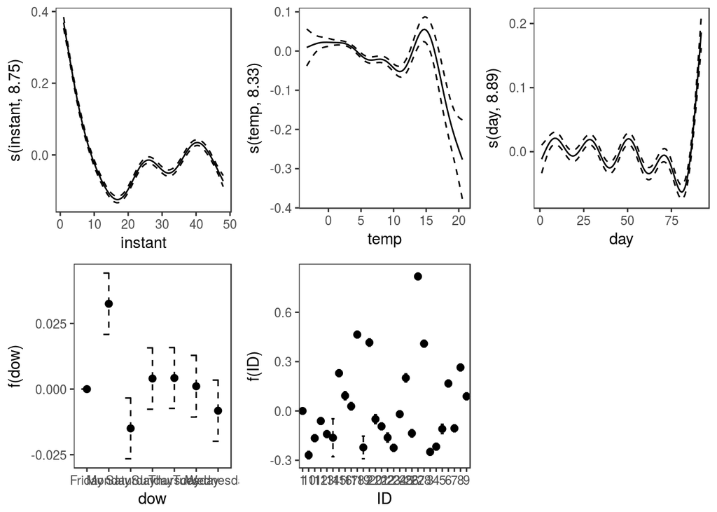

```r
library(mgcViz)
load(paste0(goodLocation, "/data/Ind_elect.rda")) # change this

fit1 <- bamV(load ~ dow + ID + s(instant) + s(temp) + s(day), data = indElec,
             aViz = list(nsim = 50))

print(plot(fit1, allTerms = TRUE), pages = 1)
```

```r
summary(fit1)
```

```
##
## Family: gaussian
## Link function: identity
##
## Formula:
## load ~ dow + ID + s(instant) + s(temp) + s(day)
##
## Parametric coefficients:
##               Estimate Std. Error t value Pr(>|t|)
## (Intercept)   0.299185   0.008380  35.704  < 2e-16 ***
## dowMonday     0.032524   0.005966   5.451 5.01e-08 ***
## dowSaturday  -0.014966   0.005908  -2.533 0.011299 *
## dowSunday     0.004036   0.005963   0.677 0.498566
## dowThursday   0.004235   0.005915   0.716 0.474044
## dowTuesday    0.001096   0.005999   0.183 0.855104
## dowWednesday -0.008221   0.005942  -1.384 0.166454
## ID2           0.416105   0.011206  37.133  < 2e-16 ***
## ID3          -0.249078   0.010498 -23.727  < 2e-16 ***
## ID4          -0.217387   0.010498 -20.708  < 2e-16 ***
## ID5          -0.109514   0.014450  -7.579 3.51e-14 ***
## ID6           0.167023   0.010498  15.911  < 2e-16 ***
## ID7          -0.105729   0.010498 -10.072  < 2e-16 ***
## ID8           0.264718   0.010498  25.217  < 2e-16 ***
## ID9           0.088920   0.010498   8.471  < 2e-16 ***
## ID10         -0.268608   0.011383 -23.598  < 2e-16 ***
## ID11         -0.165573   0.010498 -15.772  < 2e-16 ***
## ID12         -0.061226   0.010498  -5.832 5.48e-09 ***
## ID13         -0.140526   0.010498 -13.387  < 2e-16 ***
## ID14         -0.163064   0.058799  -2.773 0.005552 **
## ID15          0.229758   0.010498  21.887  < 2e-16 ***
## ID16          0.092815   0.012507   7.421 1.17e-13 ***
## ID17          0.028345   0.011383   2.490 0.012770 *
## ID18          0.464499   0.010498  44.248  < 2e-16 ***
## ID19         -0.222030   0.035078  -6.330 2.47e-10 ***
## ID20         -0.049945   0.013854  -3.605 0.000312 ***
## ID21         -0.093811   0.010498  -8.936  < 2e-16 ***
## ID22         -0.161982   0.013962 -11.602  < 2e-16 ***
## ID23         -0.224523   0.010498 -21.388  < 2e-16 ***
## ID24         -0.019538   0.010498  -1.861 0.062713 .
## ID25          0.201002   0.012507  16.071  < 2e-16 ***
## ID26         -0.135990   0.011383 -11.947  < 2e-16 ***
## ID27          0.818135   0.010498  77.936  < 2e-16 ***
## ID28          0.409240   0.010498  38.984  < 2e-16 ***
## ---
## Signif. codes:  0 '***' 0.001 '**' 0.01 '*' 0.05 '.' 0.1 ' ' 1
##
## Approximate significance of smooth terms:
##              edf Ref.df      F p-value
## s(instant) 8.752  8.982 497.32  <2e-16 ***
## s(temp)    8.331  8.826  19.81  <2e-16 ***
## s(day)     8.888  8.996  35.42  <2e-16 ***
## ---
## Signif. codes:  0 '***' 0.001 '**' 0.01 '*' 0.05 '.' 0.1 ' ' 1
##
## R-sq.(adj) =  0.262   Deviance explained = 26.3%
## fREML =  69246  Scale est. = 0.24045   n = 97772
```

All effects seem important, according to the p-values.

2. Now we use `check2D` to look at the mean residuals across two variables, we are looking for interactions between `ID` and some of the other covariates:

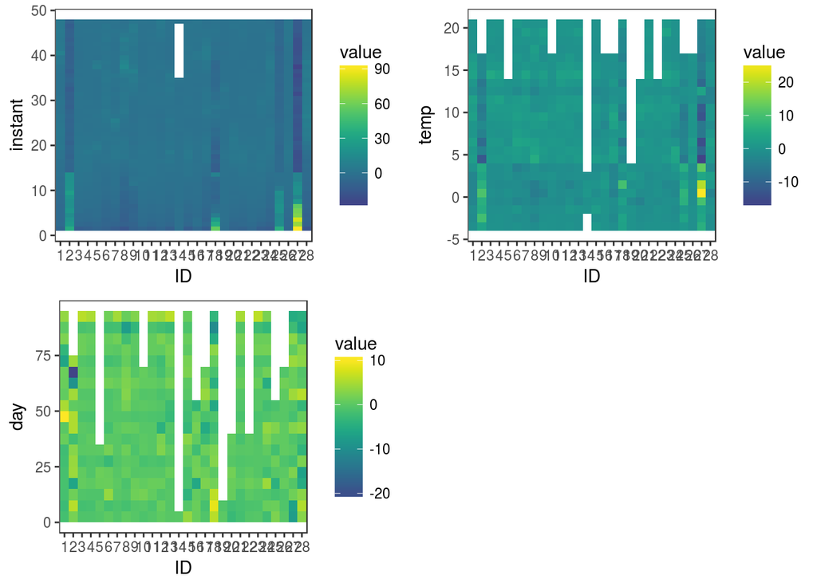

```r
pl <- list()
pl[[1]] <- check2D(fit1, "instant", "ID") + l_gridCheck2D(bw = c(NA, 1))
pl[[2]] <- check2D(fit1, "temp", "ID") + l_gridCheck2D(bw = c(NA, 1))
pl[[3]] <- check2D(fit1, "day", "ID") + l_gridCheck2D(bw = c(NA, 5))

library(gridExtra)
grid.arrange(grobs = lapply(pl, "[[", "ggObj"), ncol = 2)
```

Here the mean residuals are normalized using simulations from the model. Hence values <-2 or >2 are important, and here we have some massive deviations from zero. Costumers 2 and 27 seems particularly difficult to forecast. Let’s look at the latter:

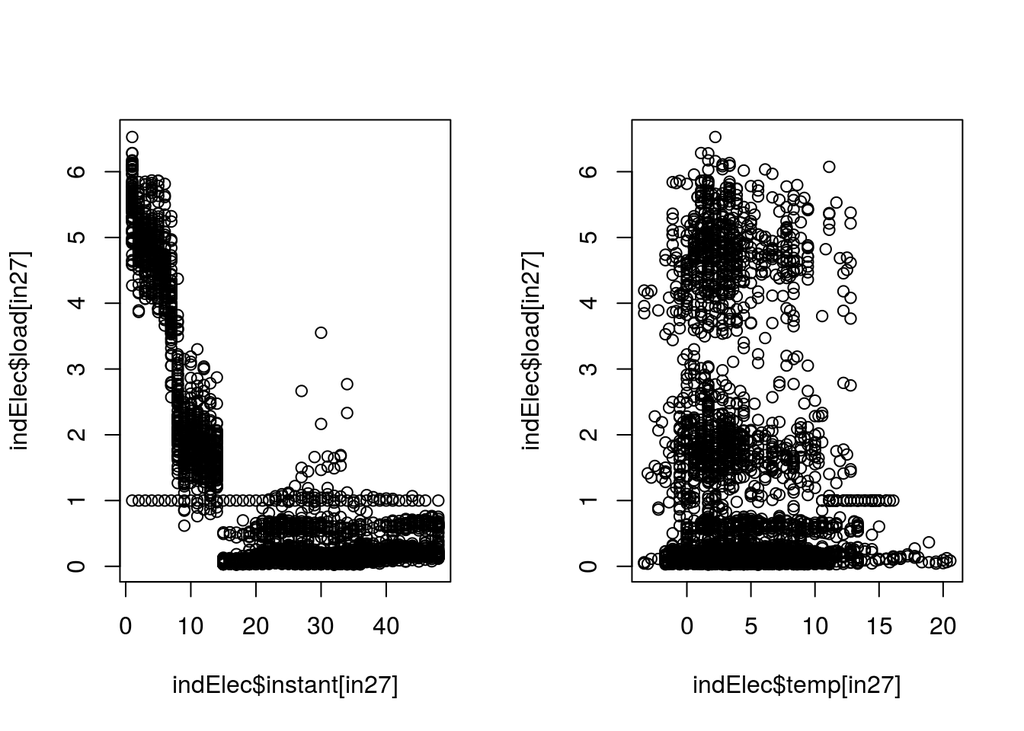

```r
in27 <- which(indElec$ID == 27)
par(mfrow = c(1, 2))
plot(indElec$instant[in27], indElec$load[in27])
plot(indElec$temp[in27], indElec$load[in27])
```

Most of the consumption happens before 7 am, and at temperatures < 12 degrees. Maybe this is due to storage heating?

3. Fit model with by-factor smooth for each costumer, but same smoothing parameter for each by-factor effect:

```r
fit2 <- bamV(load ~ dow + ID +
                    s(instant, by = ID, id = 1) +
                    s(temp, by = ID, id = 2) +
                    s(day, by = ID, id = 3), data = indElec,
             aViz = list(nsim = 50), aGam = list(discrete = TRUE))

summary(fit2)
```

```
##
## Family: gaussian
## Link function: identity
##
## Formula:
## load ~ dow + ID + s(instant, by = ID, id = 1) + s(temp, by = ID,
##     id = 2) + s(day, by = ID, id = 3)
##
## Parametric coefficients:
##               Estimate Std. Error t value Pr(>|t|)
## (Intercept)   0.263473   0.010866  24.248  < 2e-16 ***
## dowMonday     0.033019   0.003248  10.165  < 2e-16 ***
## dowSaturday  -0.015715   0.003209  -4.897 9.75e-07 ***
## dowSunday     0.005081   0.003244   1.566  0.11734
## dowThursday   0.004432   0.003212   1.380  0.16755
## dowTuesday    0.003456   0.003267   1.058  0.29015
## dowWednesday -0.008184   0.003233  -2.531  0.01137 *
## ID2           1.042239   0.060787  17.146  < 2e-16 ***
## ID3          -0.211495   0.015032 -14.069  < 2e-16 ***
## ID4          -0.189642   0.015032 -12.616  < 2e-16 ***
## ID5          -0.072416   0.871329  -0.083  0.93376
## ID6           0.175096   0.015032  11.648  < 2e-16 ***
## ID7          -0.083467   0.015032  -5.552 2.82e-08 ***
## ID8           0.257744   0.015032  17.146  < 2e-16 ***
## ID9           0.125601   0.015032   8.355  < 2e-16 ***
## ID10         -0.162192   0.090007  -1.802  0.07155 .
## ID11         -0.143106   0.015032  -9.520  < 2e-16 ***
## ID12          0.003868   0.015032   0.257  0.79695
## ID13         -0.129005   0.015032  -8.582  < 2e-16 ***
## ID14          5.764891   9.373014   0.615  0.53852
## ID15          0.232307   0.015032  15.454  < 2e-16 ***
## ID16         -0.789655   0.350286  -2.254  0.02418 *
## ID17          0.069730   0.090007   0.775  0.43851
## ID18          0.440017   0.015032  29.271  < 2e-16 ***
## ID19         -0.164369   2.531543  -0.065  0.94823
## ID20         -0.227202   0.724412  -0.314  0.75380
## ID21         -0.056523   0.015032  -3.760  0.00017 ***
## ID22         -0.273722   0.752840  -0.364  0.71617
## ID23         -0.177491   0.015032 -11.807  < 2e-16 ***
## ID24         -0.058583   0.015032  -3.897 9.74e-05 ***
```

[output cut: 83 more lines]

```
## s(day):ID19     1.004  1.007     0.000 0.989275
## s(day):ID20     4.273  4.577     2.905 0.020304 *
## s(day):ID21     8.876  8.995    10.650  < 2e-16 ***
## s(day):ID22     4.188  4.480     0.550 0.770502
## s(day):ID23     8.876  8.995    12.540  < 2e-16 ***
## s(day):ID24     8.876  8.995    22.351  < 2e-16 ***
## s(day):ID25     5.626  5.928     8.016 8.88e-09 ***
## s(day):ID26     7.307  7.660     0.289 0.970375
## s(day):ID27     8.876  8.995    33.234  < 2e-16 ***
## s(day):ID28     8.876  8.995    28.574  < 2e-16 ***
## ---
## Signif. codes:  0 '***' 0.001 '**' 0.01 '*' 0.05 '.' 0.1 ' ' 1
##
## R-sq.(adj) =  0.782   Deviance explained = 78.4%
## fREML =  11064  Scale est. = 0.070932  n = 97772
```

```r
AIC(fit1, fit2)
```

```
##             df       AIC
## fit1  61.51699 138180.88
## fit2 659.10313  19415.93
```

This seems to be a very serious improvement in AIC! We repeat the residual checks:

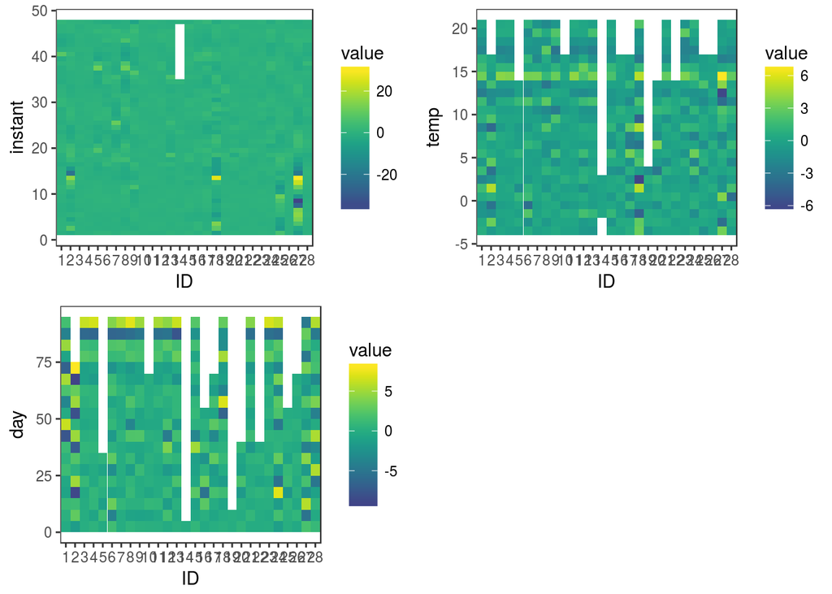

```r
pl <- list()
pl[[1]] <- check2D(fit2, "instant", "ID") + l_gridCheck2D(bw = c(NA, 1))
pl[[2]] <- check2D(fit2, "temp", "ID") + l_gridCheck2D(bw = c(NA, 1))
pl[[3]] <- check2D(fit2, "day", "ID") + l_gridCheck2D(bw = c(NA, 5))

library(gridExtra)
grid.arrange(grobs = lapply(pl, "[[", "ggObj"), ncol = 2)
```

Better than before, but we still have some very large deviations.

4. Now we look at whether we should change the bases dimension:

```r
check(fit2)
```

```
##
## Method: fREML   Optimizer: perf chol
## $grad
##               [,1]
## [1,]  2.242715e-08
## [2,]  2.122746e-12
## [3,]  1.845635e-12
## [4,] -2.612796e-08
##
## $hess
##               [,1]        [,2]         [,3]        [,4]
## [1,]   99.35701305  -0.0011219  -0.01113285  -106.76486
## [2,]   -0.00112190  31.8761971   0.24853903   -73.60106
## [3,]   -0.01113285   0.2485390  58.96207225   -89.04180
## [4,] -106.76485927 -73.6010624 -89.04179608 48827.00000
##
## Model rank =  790 / 790
##
## Basis dimension (k) checking results. Low p-value (k-index<1) may
## indicate that k is too low, especially if edf is close to k'.
##
##                   k'  edf k-index p-value
## s(instant):ID1  9.00 8.85    1.03   0.975
## s(instant):ID2  9.00 8.81    1.03   0.980
## s(instant):ID3  9.00 8.85    1.03   0.985
## s(instant):ID4  9.00 8.85    1.03   0.985
## s(instant):ID5  9.00 8.61    1.03   0.985
## s(instant):ID6  9.00 8.85    1.03   0.990
## s(instant):ID7  9.00 8.85    1.03   0.975
## s(instant):ID8  9.00 8.85    1.03   0.975
## s(instant):ID9  9.00 8.85    1.03   0.980
## s(instant):ID10 9.00 8.80    1.03   0.970
## s(instant):ID11 9.00 8.85    1.03   0.985
## s(instant):ID12 9.00 8.85    1.03   0.955
## s(instant):ID13 9.00 8.85    1.03   0.985
## s(instant):ID14 9.00 5.38    1.03   0.980
## s(instant):ID15 9.00 8.85    1.03   0.970
## s(instant):ID16 9.00 8.73    1.03   0.975
## s(instant):ID17 9.00 8.80    1.03   0.985
## s(instant):ID18 9.00 8.85    1.03   0.985
```

[output cut: 53 more lines]

```
## s(day):ID16     9.00 5.63    0.96  <2e-16 ***
## s(day):ID17     9.00 7.31    0.96  <2e-16 ***
## s(day):ID18     9.00 8.88    0.96   0.010 **
## s(day):ID19     9.00 1.00    0.96  <2e-16 ***
## s(day):ID20     9.00 4.27    0.96   0.005 **
## s(day):ID21     9.00 8.88    0.96   0.010 **
## s(day):ID22     9.00 4.19    0.96   0.010 **
## s(day):ID23     9.00 8.88    0.96  <2e-16 ***
## s(day):ID24     9.00 8.88    0.96  <2e-16 ***
## s(day):ID25     9.00 5.63    0.96   0.005 **
## s(day):ID26     9.00 7.31    0.96   0.005 **
## s(day):ID27     9.00 8.88    0.96  <2e-16 ***
## s(day):ID28     9.00 8.88    0.96   0.005 **
## ---
## Signif. codes:  0 '***' 0.001 '**' 0.01 '*' 0.05 '.' 0.1 ' ' 1
```

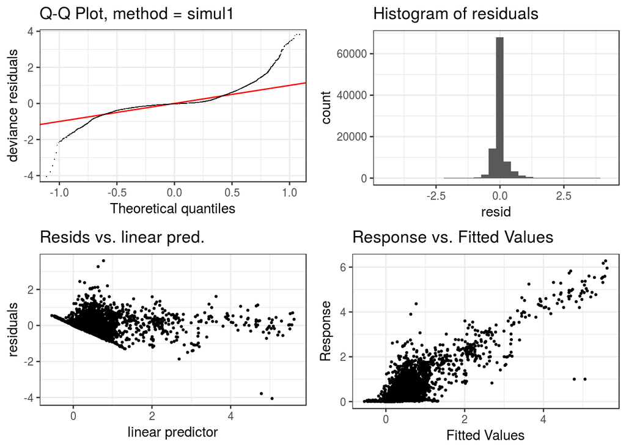

The bases for `day` might be a bit too small, and possibly also the one for `instant`. We try to increase their dimension:

```r
fit3 <- bamV(load ~ dow + ID +
                    s(instant, by = ID, id = 1, k = 20) +
                    s(temp, by = ID, id = 2) +
                    s(day, by = ID, id = 3, k = 20), data = indElec,
             aViz = list(nsim = 50), aGam = list(discrete = TRUE))

AIC(fit2, fit3)
```

```
##             df       AIC
## fit2  659.1031 19415.926
## fit3 1097.5461  8989.751
```

```r
check(fit3)
```

```
##
## Method: fREML   Optimizer: perf chol
## $grad
##               [,1]
## [1,] -3.013145e-11
## [2,] -1.122658e-11
## [3,]  1.311671e-10
## [4,]  2.546585e-10
##
## $hess
##               [,1]         [,2]          [,3]        [,4]
## [1,]  1.994108e+02   0.03839932  9.373476e-03  -230.67544
## [2,]  3.839932e-02  25.60646912  1.442130e+00   -67.05466
## [3,]  9.373476e-03   1.44213037  1.505795e+02  -190.84808
## [4,] -2.306754e+02 -67.05466387 -1.908481e+02 48827.00000
##
## Model rank =  1350 / 1350
##
## Basis dimension (k) checking results. Low p-value (k-index<1) may
## indicate that k is too low, especially if edf is close to k'.
##
##                    k'   edf k-index p-value
## s(instant):ID1  19.00 18.17    0.99    0.25
## s(instant):ID2  19.00 17.98    0.99    0.24
## s(instant):ID3  19.00 18.17    0.99    0.26
## s(instant):ID4  19.00 18.17    0.99    0.22
## s(instant):ID5  19.00 17.11    0.99    0.22
## s(instant):ID6  19.00 18.17    0.99    0.24
## s(instant):ID7  19.00 18.17    0.99    0.26
## s(instant):ID8  19.00 18.17    0.99    0.23
## s(instant):ID9  19.00 18.17    0.99    0.26
## s(instant):ID10 19.00 17.94    0.99    0.24
## s(instant):ID11 19.00 18.17    0.99    0.27
## s(instant):ID12 19.00 18.17    0.99    0.23
## s(instant):ID13 19.00 18.17    0.99    0.25
## s(instant):ID14 19.00  8.85    0.99    0.23
## s(instant):ID15 19.00 18.17    0.99    0.28
## s(instant):ID16 19.00 17.63    0.99    0.30
## s(instant):ID17 19.00 17.94    0.99    0.24
## s(instant):ID18 19.00 18.17    0.99    0.28
```

[output cut: 51 more lines]

```
## s(day):ID14     19.00  1.00    0.99    0.18
## s(day):ID15     19.00 18.06    0.99    0.16
## s(day):ID16     19.00 10.49    0.99    0.16
## s(day):ID17     19.00 13.97    0.99    0.16
## s(day):ID18     19.00 18.06    0.99    0.26
## s(day):ID19     19.00  1.19    0.99    0.19
## s(day):ID20     19.00  7.95    0.99    0.20
## s(day):ID21     19.00 18.06    0.99    0.17
## s(day):ID22     19.00  7.77    0.99    0.17
## s(day):ID23     19.00 18.06    0.99    0.20
## s(day):ID24     19.00 18.06    0.99    0.17
## s(day):ID25     19.00 10.49    0.99    0.19
## s(day):ID26     19.00 13.97    0.99    0.20
## s(day):ID27     19.00 18.06    0.99    0.14
## s(day):ID28     19.00 18.06    0.99    0.16
```

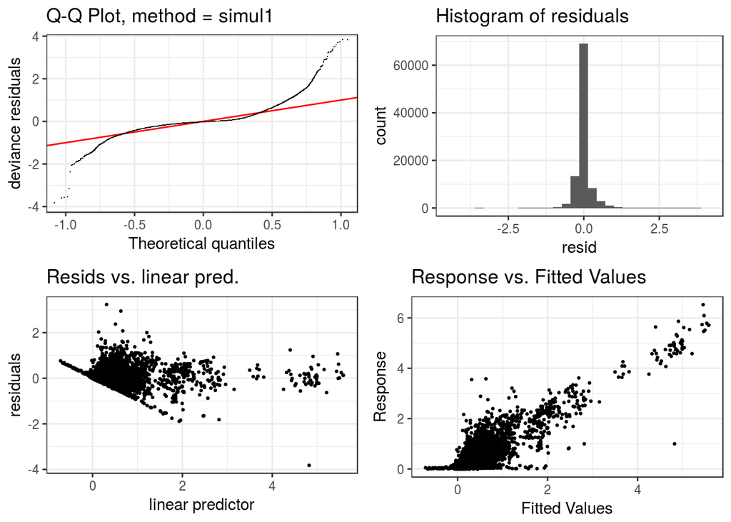

AIC is much lower, and the p-values reported by `check` are not significant now.

4. We might consider including the effect of the lagged smoothed load:

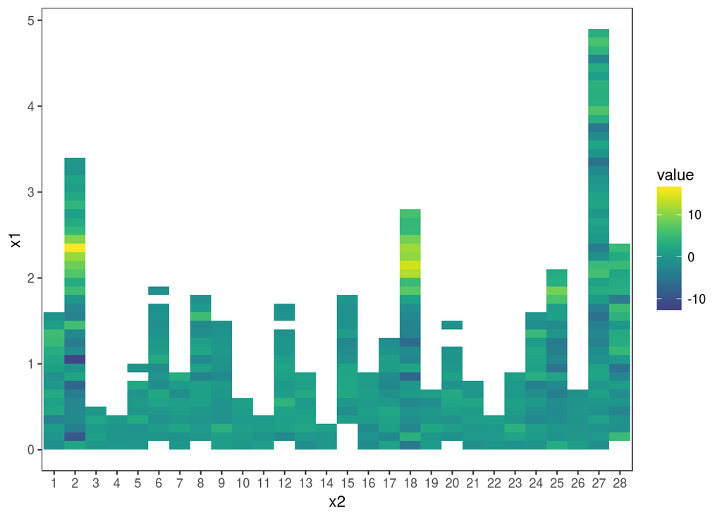

```r
check2D(fit3, indElec$load48SM, indElec$ID) + l_gridCheck2D(bw = c(NA, 0.1))
```

Smoothed load seems to be important, especially for households 2 and 18. We include a by-factor effect of smoothed load:

```r
fit4 <- bamV(load ~ dow + ID +
                    s(instant, by = ID, id = 1, k = 20) +
                    s(temp, by = ID, id = 2) +
                    s(day, by = ID, id = 3, k = 20) +
                    s(load48SM, by = ID, id = 4), data = indElec,
             aViz = list(nsim = 50), aGam = list(discrete = TRUE))

AIC(fit3, fit4)
```

```
##            df      AIC
## fit3 1097.546 8989.751
## fit4 1157.393 2661.545
```

Big improvement in AIC. We re-check the mean of the residuals:

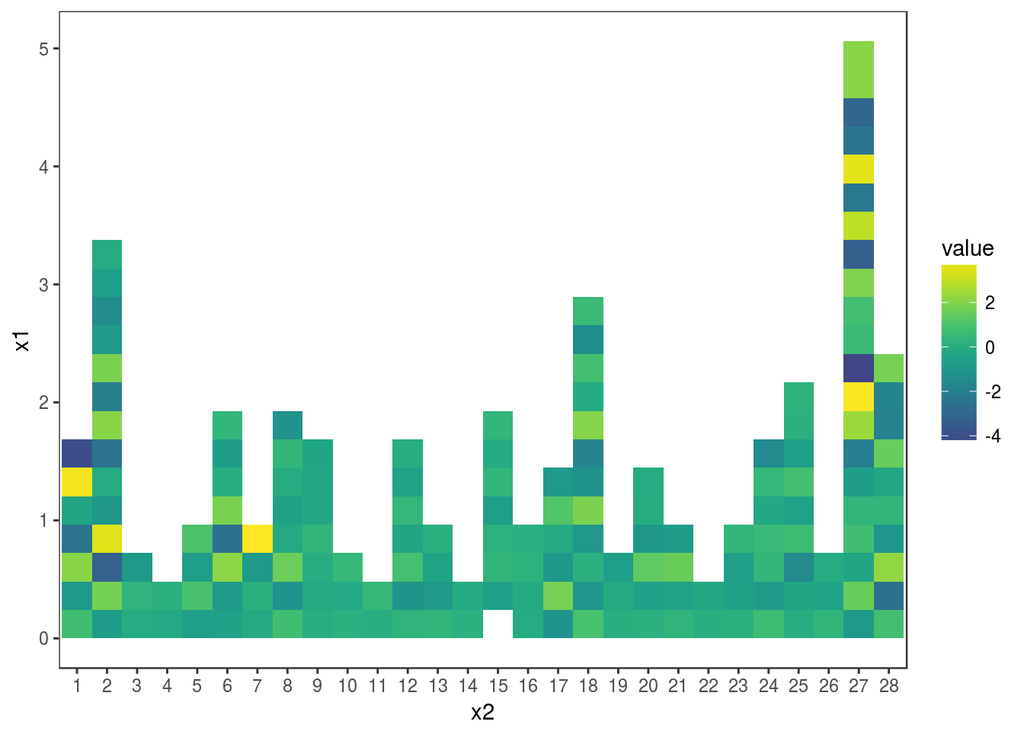

```r
check2D(fit4, indElec$load48SM, indElec$ID) + l_gridCheck2D()
```

Deviations are now in the range [-4,+4], still large, but better than before.

5. Looking at some individual consumptions and predictions. Change the loop indexes to look at different costumers:

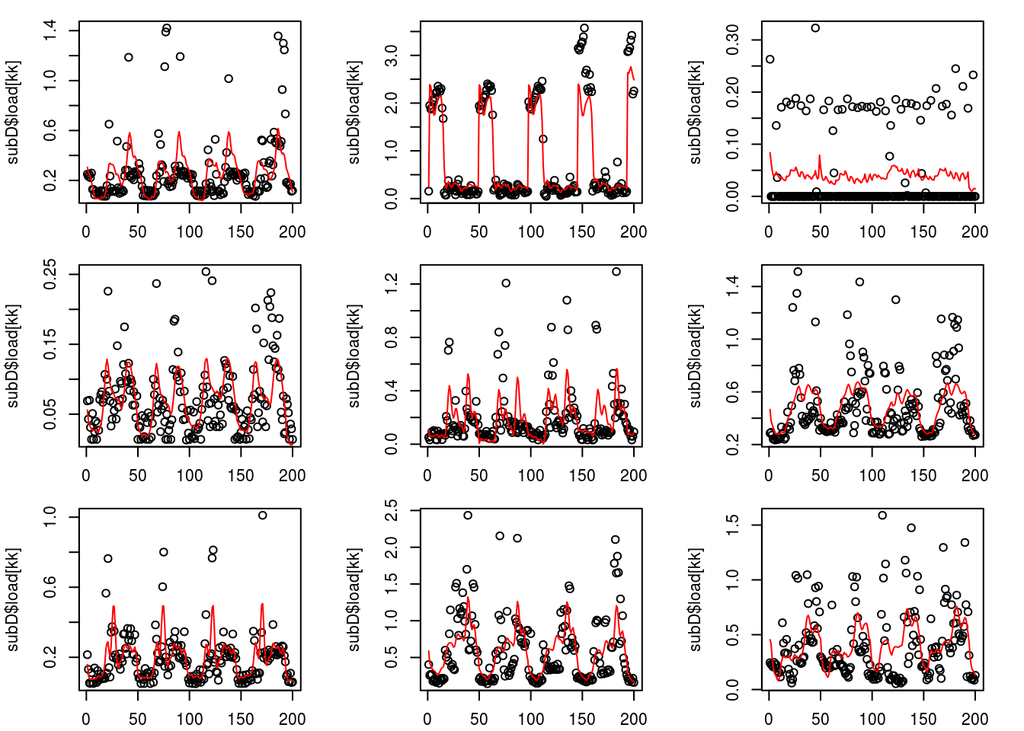

```r
par(mfrow = c(3, 3), mar = c(2.1, 4.1, 1.1, 2.1))
for(ID in 1:9){
  ids <- which( indElec$ID == ID )
  subD <- indElec[ids, ]
  subP <- fit4$fitted.values[ids]

  kk <- 1:200
  plot(subD$load[kk])
  lines(subP[kk], col = 2)
}
```

Costumer 3 is arguably quite hard to forecast!